# Basics of linear regression

### Dataset and first model

Check [this article](https://feliperego.github.io/blog/2015/10/23/Interpreting-Model-Output-In-R) for more details.

### Glossary:

1. **residuals**  
   Are differences between actual observation and prediction of the model.  
   Expectation: good model has mean residual close to zero
2. **coefficients**  
   One per column in data. Intercept = free term. Standard error describes uncertainity of every coefficient estimate. Expectation: small Std. error
3. **t-value**  
   How many standard deviations from 0 is this coefficient? Being far from zero suggests existence of a relationship. See *Null Hypothesis*.
4. **Pr(>t) or p-value**  
   Probability that observed value is larger than t-value. A small p-value indicates that it is unlikely we will observe a relationship between the predictor and response due to chance. Expectation: as low as possible, 0.05 being a common cut-off.
5. **Residual Standard error**  
   Is the average amount that the response will deviate from the true regression line.
6. **Multiple R-squared**  
   It always lies between 0 and 1 - it represents what fraction of the observed variance is “explained” by the model. Expectation: a number close to 1.  
   *Warning*: in multiple regression settings, the $R^2$ will always increase as more variables are included in the model. **Adjusted** $R^2$ compensates for that.
7. **F-static**  
   Another indicator of relationship. Obtained by comparing the full model with models obtained from subsets of predictor variables.  
   The further the F-statistic is from 1 the better it is.  
   Generally, when the number of data points is large, an F-statistic that is only a little bit larger than 1 is already sufficient to reject the null hypothesis.

### Polynomial regression

**Problem:** not everything is connected by linear functions of variables.  
**Solution:** introduce models with higher powers of predictor variables i.e.  
$y = \beta_0 + \beta_1 x + \beta_2 x^2$  
**Problems:**  
1. $x$ and $x^2$ are often correlated, spoiling predictive power of the model.  
2. Overfitting with too high degree.  
* may try to increase max degree until coefficients become insignifficant, yet:  
* adding extra term changes all the coefficients because they’re correlated  
**Solution:** use orthogonal polynomials of each random variable.

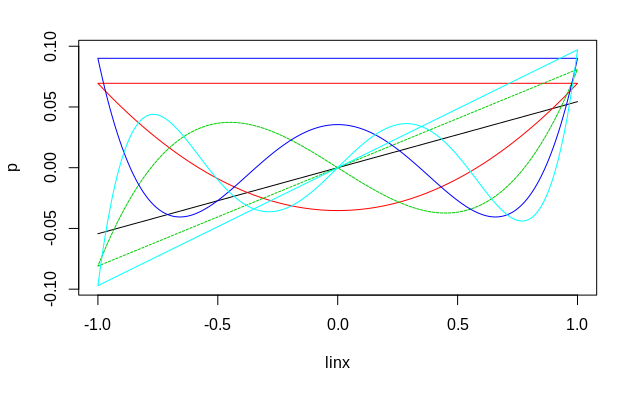

Each column of `poly()` contains linear combinations of the sequence $(x, x^2, x^3)$ independent of each other and of constant vector:

```
  e 1 2 3
e 1 0 0 0
1 0 1 0 0
2 0 0 1 0
3 0 0 0 1
```

Beware of peculiarities in naming when using `predict()`:

```r
x <- 1:100
y <- x**2
data <- data.frame(x, y) # this automatically creates column names "x" and "y"
fit <- lm(y ~ poly(x, 2), data = data)
```

Now, to use this model on a predict dataset you need a df with exactly the same column names

```r
predict(fit, newdata)
```

```
  1   2   3   4   5   6   7   8   9  10
  1   4   9  16  25  36  49  64  81 100
```